# Apresentação Pública

Luidy

2022-10-04

## Objeto

De uma forma ampla, o presente trabalho permite analisar a correlação entre participação política e a presença de igrejas protestantes e católicas e como as suas presenças contribuem para a formação de lideranças políticas, sejam elas comunitárias ou parlamentares. Uma vez que participação política pode ser lida como uma variável central para as democracias, de uma forma ampla podemos pensar como que a presença das variáveis religiosas contribui para a formação das democracias. De uma forma ampla, podemos pensar a análise da correlação entre protestantismo e democracia, uma vez que a presença protestante histórica favorece o desenvolvimento das chamadas habilidades cívicas? Esta hipótese deve ser testada para o Brasil, à luz do trabalho desenvolvido por Sidney Verba at. al (1993).

## Objetivo

Como objetivos específicos, citamos a relação de causa entre aquisição de habilidades cívicas dentro das instituições religiosas e participação política, seja ela parlamentar ou comunitária. Investigar algumas trajetórias de parlamentares a fim de analisarmos se as suas participações prévias em ambientes institucionais religiosos de que são provenientes puderam contribuir de alguma maneira na aquisição das chamadas habilidades cívicas, as quais são úteis para o exercício das suas lideranças no Congresso Nacional e na Câmara Distrital, que foram os ambientes escolhidos para a realização de parte da pesquisa.

## Contexto: Igrejas Protestantes e Democracias Liberais

Este trabalho visa tratar um pouco acerca das hipóteses desenvolvidas por Sidney Verba et (1993), em que ele testa a hipótese para a realidade norte-americana de que os protestantes, por estarem articulados em denominações religiosas mais horizontalizadas e menos hierarquizadas são passíveis de desenvolverem maiores habilidades cívicas dentro destas denominações. Estas habilidades são úteis para a política parlamentar e para a política desenvolvida também nas bases das comunidades, por exemplo em associações de bairro. Para isto, utilizaremos algumas surveys, como a do Lapop e A Cara da Democracia.

## LAPOP: Tabela Religião e Gênero

```r
tab_xtab(var.row = X2016_17_Stata$Religião,
         var.col = X2016_17_Stata$Gênero,
         show.row.prc = T)
```

| Religião | Gênero |  | Total |  |
| --- | --- | --- | --- | --- |
|  | Feminino | Masculino |  |  |
| Africanas | 9 50 % | 9 50 % |  | 18 100 % |
| Ateu | 0 0 % | 9 100 % | 9 100 % |  |
| Católico | 183 39.4 % | 281 60.6 % | 464 100 % |  |
| Espírita | 12 57.1 % | 9 42.9 % | 21 100 % |  |
| Evangélica | 75 44.4 % | 94 55.6 % | 169 100 % |  |
| Nenhuma | 21 32.3 % | 44 67.7 % | 65 100 % |  |
| Outra | 11 57.9 % | 8 42.1 % | 19 100 % |  |
| Protestante | 30 39.5 % | 46 60.5 % | 76 100 % |  |
| Testemunha de Jeová | 3 30 % | 7 70 % | 10 100 % |  |
| Total | 344 40.4 % | 507 59.6 % | 851 100 % |  |

## Gráfico contagem religião

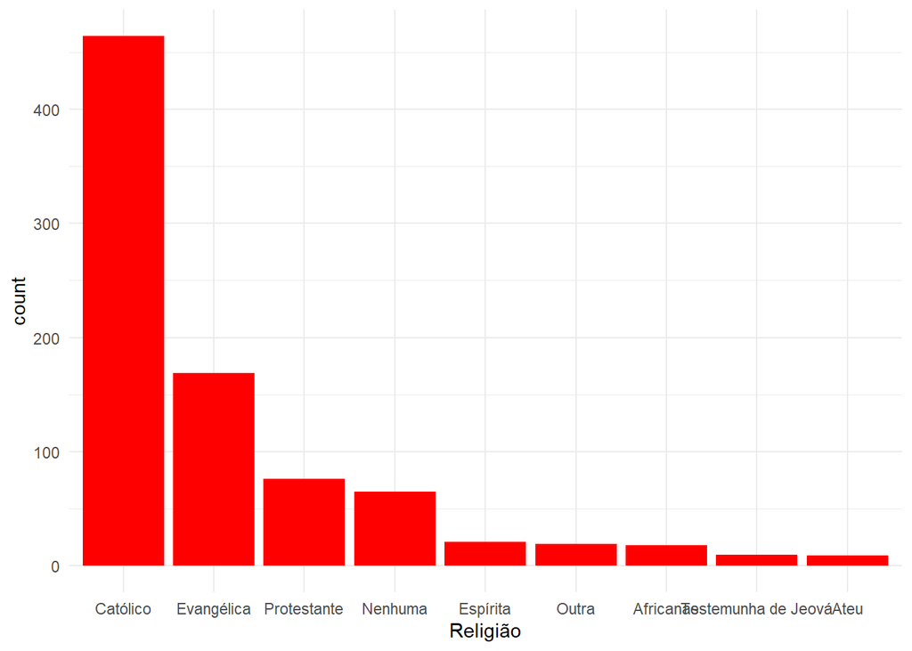

```r
ggplot(X2016_17_Stata, aes(x=reorder(Religião, Religião, function(x)-length(x)))) +
  geom_bar(fill='red') +  labs(x='Religião') + theme_minimal()
```

## Renda e religião

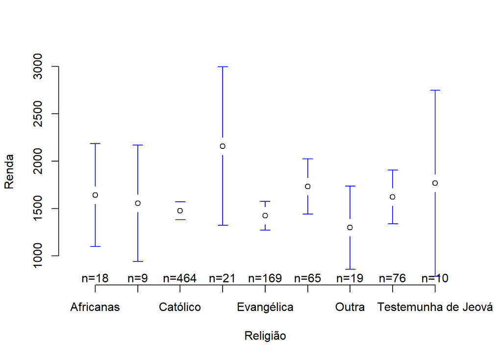

```r
plotmeans(Renda ~ Religião, data= X2016_17_Stata, frame = FALSE, connect = FALSE)
```

## Participação Política e Religião

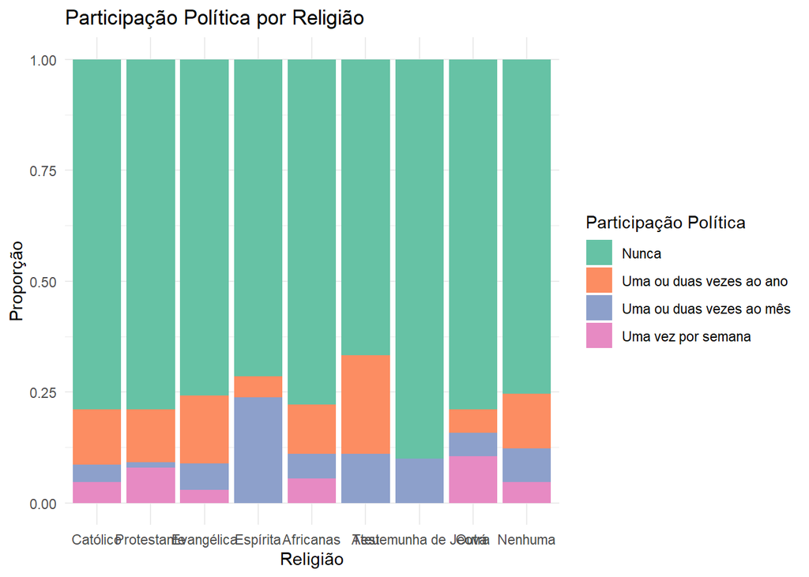

```r
ggplot(X2016_17_Stata,
       aes(x = factor(Religião,
                      levels = c("Católico", "Protestante",
                                 "Evangélica", "Espírita",
                                 "Africanas", "Ateu", "Testemunha de Jeová",
                                 "Outra", "Nenhuma")),
           fill = factor(Participação))) +
  geom_bar(position = "fill") +
  scale_fill_brewer(palette = "Set2") +
  labs(y = "Proporção",
       fill = "Participação Política",
       x = "Religião",
       title = "Participação Política por Religião") +
  theme_minimal()
```

## Conclusões

Como principais conclusões, podemos pensar que, dado os gráficos e as tabelas de regressão presentes no texto do blog e a insignificância, por vezes, estatística para a participação política e atividades comunitárias advindas de ambientes protestantes e católicos, caberia repensar a hipótese de Sidney Verba et al. (1993) para o caso brasileiro, dado que estes dois ambientes religiosos citados não necessariamente induzem à aquisição de habilidades cívicas, da mesma maneira que comparando-os para o contexto dos Estados Unidos, em que a diferença da cultura protestante e católica é marcante. Para o contexto brasileiro, pudemos observar outras relações de significância estatística, como por exemplo para a participação de espíritas e de fiéis advindos de denominações afro-nativas na política. Isto pode indicar que certamente tenhamos outras peculiaridades culturais que fazem com que o Brasil e o contexto da aquisição de habilidades cívicas e da participação política a partir de ambientes institucionais da religião mereça ser estudado e considerado com mais atenção a alguns detalhes como este da participação espírita e de religiões afro-nativas.